# Customer_Analytics

Anugya Shaw

21/07/2020

###R Markdown - Data preparation and Customer Analytics The client is a Category Manager for Chips, who wants to identify target customers and understand the type of customers who purchased Chips and their purchasing behaviour within the region. The data consists of customer transactions and purchasing behaviour. It consists of transaction from 1st July, 2018 to 30th June, 2019.

###Loading necessary libraries

```r
#loading necessary library
library(readxl)
library(data.table)
library(dplyr)
```

```r
library(ggplot2)
library(ggmosaic)
library(readr)
```

#point the file path to read data

```r
#point the file path to read data
filePath <- "C:\\Users\\Anugya\\Downloads\\Quantium\\"
transactionData <- fread(paste0(filePath,"QVI_transaction_data.csv"))

View(transactionData)
```

```r
#Structure of data
str(transactionData)
```

```
## Classes 'data.table' and 'data.frame':   264836 obs. of  10 variables:
##  $ DATE            : chr  "17-10-2018" "14-05-2019" "20-05-2019" "17-08-2018" ...
##  $ STORE_NBR       : int  1 1 1 2 2 4 4 4 5 7 ...
##  $ LYLTY_CARD_NBR  : int  1000 1307 1343 2373 2426 4074 4149 4196 5026 7150 ...
##  $ TXN_ID          : int  1 348 383 974 1038 2982 3333 3539 4525 6900 ...
##  $ PROD_NBR        : int  5 66 61 69 108 57 16 24 42 52 ...
##  $ PROD_NAME       : chr  "Natural Chip Compny SeaSalt175g" "CCs Nacho Cheese 175g" "Smiths Crinkle Cut Chips Chicken 170g" "Smiths Chip Thinly S/Cream&Onion 175g" ...
##  $ PROD_QTY        : int  2 3 2 5 3 1 1 1 1 2 ...
##  $ TOT_SALES       : num  6 6.3 2.9 15 13.8 5.1 5.7 3.6 3.9 7.2 ...
##  $ LIFESTAGE       : chr  "YOUNG SINGLES/COUPLES" "MIDAGE SINGLES/COUPLES" "MIDAGE SINGLES/COUPLES" "MIDAGE SINGLES/COUPLES" ...
##  $ Premium_customer: chr  "Premium" "Budget" "Budget" "Budget" ...
##  - attr(*, ".internal.selfref")=<externalptr>
```

###Data Cleaning and Preparation

```r
#Change format of date
transactionData$DATE <- as.Date(transactionData$DATE, format= "%d-%m-%Y")
```

```r
#Summary of field PROD_NAME
transactionData[ ,.N,PROD_NAME]
```

```
##                                     PROD_NAME    N
##   1:          Natural Chip Compny SeaSalt175g 1468
##   2:                    CCs Nacho Cheese 175g 1498
##   3:    Smiths Crinkle Cut Chips Chicken 170g 1484
##   4:    Smiths Chip Thinly S/Cream&Onion 175g 1473
##   5: Kettle Tortilla ChpsHny&Jlpno Chili 150g 3296
##  ---
## 110:    Red Rock Deli Chikn&Garlic Aioli 150g 1434
## 111:          RRD SR Slow Rst Pork Belly 150g 1526
## 112:                     RRD Pc Sea Salt 165g 1431
## 113:         Smith Crinkle Cut Bolognese 150g 1451
## 114:                  Doritos Salsa Mild 300g 1472
```

```r
#to check if these products are only chips
productWords <- data.table(unlist(strsplit(unique(transactionData[, PROD_NAME]), "
")))

#Removing Digits
productWords <- gsub('[0-9]+', '', productWords)

#Removing special characters
productWords <- gsub("[[:punct:]]", " ", productWords)

#Sorting in the frequency of Occurences
words <- names(sort(table(productWords), decreasing=TRUE))
words
```

[output not shown]

There are Salsa products in the list but we require only Chips products. So lets remove Salsa products.

```r
#remove Salsa products
transactionData[, SALSA := grepl("salsa", tolower(PROD_NAME))]
transactionData <‐ transactionData[SALSA == FALSE, ][, SALSA := NULL]
```

We will now check summary statistics for the dataset.

```r
#Summarise the data to check for nulls and possible outliers
summary(transactionData)
```

```
##       DATE              STORE_NBR     LYLTY_CARD_NBR        TXN_ID
##  Min.   :2018-07-01   Min.   :  1.0   Min.   :   1000   Min.   :      1
##  1st Qu.:2018-09-30   1st Qu.: 70.0   1st Qu.:  70015   1st Qu.:  67569
##  Median :2018-12-30   Median :130.0   Median : 130367   Median : 135183
##  Mean   :2018-12-30   Mean   :135.1   Mean   : 135531   Mean   : 135131
##  3rd Qu.:2019-03-31   3rd Qu.:203.0   3rd Qu.: 203084   3rd Qu.: 202654
##  Max.   :2019-06-30   Max.   :272.0   Max.   :2373711   Max.   :2415841
##     PROD_NBR       PROD_NAME            PROD_QTY         TOT_SALES
##  Min.   :  1.00   Length:246742      Min.   :  1.000   Min.   :  1.700
##  1st Qu.: 26.00   Class :character   1st Qu.:  2.000   1st Qu.:  5.800
##  Median : 53.00   Mode  :character   Median :  2.000   Median :  7.400
##  Mean   : 56.35                      Mean   :  1.908   Mean   :  7.321
##  3rd Qu.: 87.00                      3rd Qu.:  2.000   3rd Qu.:  8.800
##  Max.   :114.00                      Max.   :200.000   Max.   :650.000
##   LIFESTAGE         Premium_customer
##  Length:246742      Length:246742
##  Class :character   Class :character
##  Mode  :character   Mode  :character
##
##
##
```

```r
is.null(transactionData)
```

```
## [1] FALSE
```

There are no null values but PROD_QTY appears to have a outlier, so lets filter it out.

```r
#filter outliers--- Where prod quantity = 200
filter(transactionData,PROD_QTY == 200)
```

```
##         DATE STORE_NBR LYLTY_CARD_NBR TXN_ID PROD_NBR
## 1 2018-08-19       226         226000 226201        4
## 2 2019-05-20       226         226000 226210        4
##                      PROD_NAME PROD_QTY TOT_SALES      LIFESTAGE
## 1 Dorito Corn Chp Supreme 380g      200       650 OLDER FAMILIES
## 2 Dorito Corn Chp Supreme 380g      200       650 OLDER FAMILIES
##   Premium_customer
## 1          Premium
## 2          Premium
```

There are two transaction with Product quantity = 200, having the same customer. So lets check other transaction of the customer with Loyalty Card Number - 226000

```r
#filter outliers for transactions from above customer
filter(transactionData, LYLTY_CARD_NBR == 226000)
```

```
##         DATE STORE_NBR LYLTY_CARD_NBR TXN_ID PROD_NBR
## 1 2018-08-19       226         226000 226201        4
## 2 2019-05-20       226         226000 226210        4
##                      PROD_NAME PROD_QTY TOT_SALES      LIFESTAGE
## 1 Dorito Corn Chp Supreme 380g      200       650 OLDER FAMILIES
## 2 Dorito Corn Chp Supreme 380g      200       650 OLDER FAMILIES
##   Premium_customer
## 1          Premium
## 2          Premium
```

It looks like this customer has only had the two transactions over the year and is not an ordinary retail customer. The customer might be buying chips for commercial purposes instead. We’ll remove this loyalty card number from further analysis.

```r
#Removing theat loyalt card number
transactionData <- transactionData[LYLTY_CARD_NBR != 226000, ]
# Re‐examine transaction data
summary(transactionData)
```

```
##       DATE              STORE_NBR     LYLTY_CARD_NBR        TXN_ID
##  Min.   :2018-07-01   Min.   :  1.0   Min.   :   1000   Min.   :      1
##  1st Qu.:2018-09-30   1st Qu.: 70.0   1st Qu.:  70015   1st Qu.:  67569
##  Median :2018-12-30   Median :130.0   Median : 130367   Median : 135182
##  Mean   :2018-12-30   Mean   :135.1   Mean   : 135530   Mean   : 135130
##  3rd Qu.:2019-03-31   3rd Qu.:203.0   3rd Qu.: 203083   3rd Qu.: 202652
##  Max.   :2019-06-30   Max.   :272.0   Max.   :2373711   Max.   :2415841
##     PROD_NBR       PROD_NAME            PROD_QTY       TOT_SALES
##  Min.   :  1.00   Length:246740      Min.   :1.000   Min.   : 1.700
##  1st Qu.: 26.00   Class :character   1st Qu.:2.000   1st Qu.: 5.800
##  Median : 53.00   Mode  :character   Median :2.000   Median : 7.400
##  Mean   : 56.35                      Mean   :1.906   Mean   : 7.316
##  3rd Qu.: 87.00                      3rd Qu.:2.000   3rd Qu.: 8.800
##  Max.   :114.00                      Max.   :5.000   Max.   :29.500
##   LIFESTAGE         Premium_customer
##  Length:246740      Length:246740
##  Class :character   Class :character
##  Mode  :character   Mode  :character
##
##
##
```

Now we will look at the transaction lines to check if there is any missing date.

```r
#Count transactions by Date
counts<-data.frame(table(transactionData$DATE))
counts
```

```
##           Var1 Freq
## 1   2018-07-01  663
## 2   2018-07-02  650
## 3   2018-07-03  674
## 4   2018-07-04  669
## 5   2018-07-05  660
## 6   2018-07-06  711
## 7   2018-07-07  695
## 8   2018-07-08  653
## 9   2018-07-09  692
## 10  2018-07-10  650
## 11  2018-07-11  701
## 12  2018-07-12  717
## 13  2018-07-13  727
## 14  2018-07-14  661
```

[output cut: 350 more lines]

There are only 364 rows which means transaction for a single date is missing.Lets plot trasancation over time to fing the missing date.

```r
#Sequence of dates and frequency
trans_by_day <- counts[order(as.Date(counts$Var1, format="%Y-%m-%d")),]
trans_by_day$Date <- as.Date(trans_by_day$Var1, origin = "30-12-1899")
str(trans_by_day)
```

```
## 'data.frame':    364 obs. of  3 variables:
##  $ Var1: Factor w/ 364 levels "2018-07-01","2018-07-02",..: 1 2 3 4 5 6 7 8 9 10 ...
##  $ Freq: int  663 650 674 669 660 711 695 653 692 650 ...
##  $ Date: Date, format: "2018-07-01" "2018-07-02" ...
```

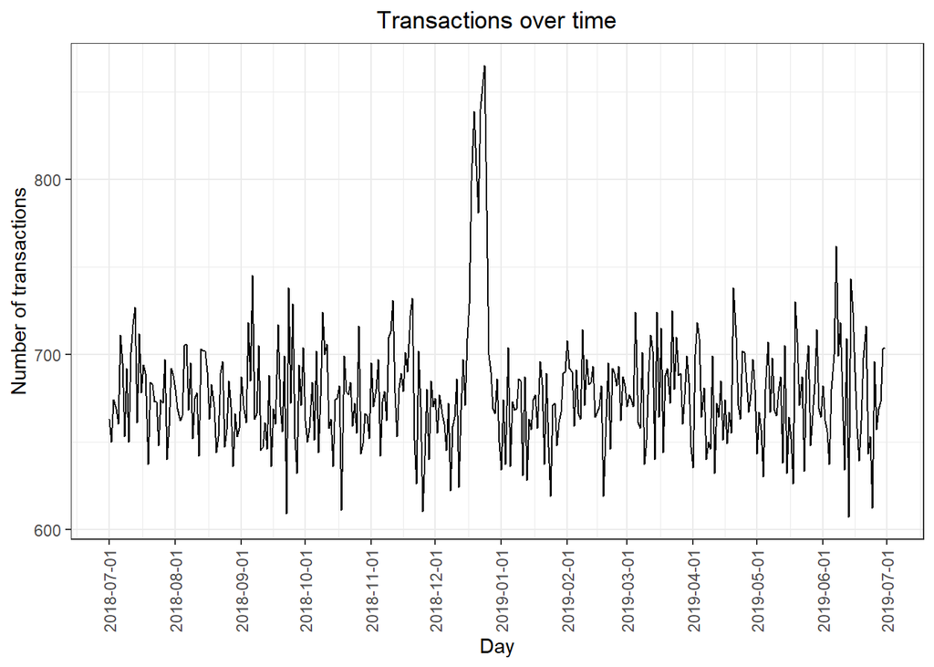

```r
#### Setting plot themes to format graphs
theme_set(theme_bw())
theme_update(plot.title = element_text(hjust = 0.5))

#### Plot transactions over time
ggplot(trans_by_day, aes(x = Date, y = Freq)) +
  geom_line()  +
  labs(x = "Day", y = "Number of transactions", title = "Transactions over time") +
  scale_x_date(breaks = "1 month") +
  theme(axis.text.x = element_text(angle = 90, vjust = 0.5))
```

We can see an increase in purchase of chips around November-December, but in late december there is sudden drop in the sale due to the holiday season. Now we will create other features like brand of chips and Packet size for further analysis. We will start with PACK_SIZE

```r
#Create Pack Size
transactionData[, PACK_SIZE := parse_number(PROD_NAME)]
#Check order
transactionData[, .N, PACK_SIZE][order(PACK_SIZE)]
```

```
##     PACK_SIZE     N
##  1:        70  1507
##  2:        90  3008
##  3:       110 22387
##  4:       125  1454
##  5:       134 25102
##  6:       135  3257
##  7:       150 40203
##  8:       160  2970
##  9:       165 15297
## 10:       170 19983
## 11:       175 66390
## 12:       180  1468
## 13:       190  2995
## 14:       200  4473
## 15:       210  6272
## 16:       220  1564
## 17:       250  3169
## 18:       270  6285
## 19:       330 12540
## 20:       380  6416
```

The largest packet size is 380 gms and smallest packet size is 70 gms. Let’s plot a histogram of PACK_SIZE since we know that it is a categorical variable and not a continuous variable even though it is numeric.

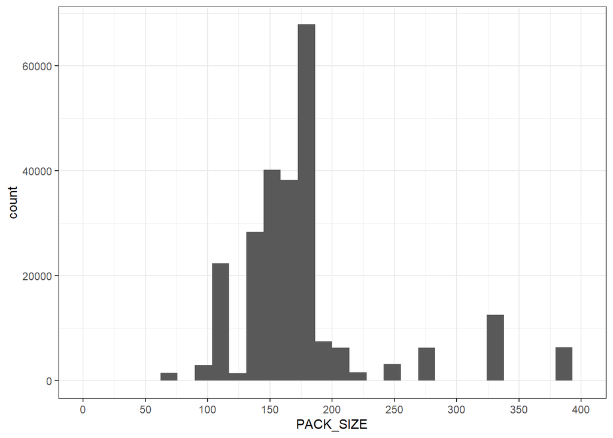

```r
#Histogram plot
ggplot(aes(x = PACK_SIZE), data = transactionData, binwidth = 50) +
 geom_histogram()+
  scale_x_continuous(limits = c(0,400), breaks = seq(0,400,50))
```

Pack sizes from 160 -180 gms have the highest frequency. SO we ca nsay it is the most preferred choince among customers. We can use the first word in PROD_NAME to work out the brand name.

```r
#Create Brand Column
transactionData$BRAND<- gsub("([A-Za-z]+).*", "\\1", transactionData$PROD_NAME)
unique(transactionData$BRAND)
```

```
##  [1] "Natural"    "CCs"        "Smiths"     "Kettle"     "Grain"
##  [6] "Doritos"    "Twisties"   "WW"         "Thins"      "Burger"
## [11] "NCC"        "Cheezels"   "Infzns"     "Red"        "Pringles"
## [16] "Dorito"     "Infuzions"  "Smith"      "GrnWves"    "Tyrrells"
## [21] "Cobs"       "French"     "RRD"        "Tostitos"   "Cheetos"
## [26] "Woolworths" "Snbts"      "Sunbites"
```

Some of the brand names like Snbts and Sunbites are same but mentioned differently so it is required to clean the brand names.

```r
#### Clean brand names
transactionData[ BRAND == "Red", BRAND := "RRD"]
transactionData[ BRAND == "Dorito", BRAND := "Doritos"]
transactionData[ BRAND == "Snbts", BRAND := "Sunbites"]
transactionData[ BRAND == "Infzns", BRAND := "Infuzions"]
transactionData[BRAND == "WW", BRAND := "WOOLWORTHS"]
transactionData[BRAND == "Woolworths", BRAND := "WOOLWORTHS"]
transactionData[BRAND == "SMITH", BRAND := "SMITHS"]
transactionData[BRAND == "NCC", BRAND := "NATURAL"]
transactionData[BRAND == "Natural", BRAND := "NATURAL"]
transactionData[BRAND == "GRAIN", BRAND := "GRNWVES"]

#Check the corrected names
transactionData[, .N, by = BRAND][order(BRAND)]
```

```
##          BRAND     N
##  1:     Burger  1564
##  2:        CCs  4551
##  3:    Cheetos  2927
##  4:   Cheezels  4603
##  5:       Cobs  9693
##  6:    Doritos 25224
##  7:     French  1418
##  8:      Grain  6272
##  9:    GrnWves  1468
## 10:  Infuzions 14201
## 11:     Kettle 41288
## 12:    NATURAL  7469
## 13:   Pringles 25102
## 14:        RRD 16321
## 15:      Smith  2963
## 16:     Smiths 27390
## 17:   Sunbites  3008
## 18:      Thins 14075
## 19:   Tostitos  9471
## 20:   Twisties  9454
## 21:   Tyrrells  6442
## 22: WOOLWORTHS 11836
##          BRAND     N
```

Let’s have a closer look at the LIFESTAGE and PREMIUM_CUSTOMER columns.

```r
transactionData[, .N, by = LIFESTAGE][order(‐N)]
```

```
##                 LIFESTAGE     N
## 1:  OLDER SINGLES/COUPLES 50793
## 2:               RETIREES 46431
## 3:         OLDER FAMILIES 45158
## 4:         YOUNG FAMILIES 40494
## 5:  YOUNG SINGLES/COUPLES 33969
## 6: MIDAGE SINGLES/COUPLES 23398
## 7:           NEW FAMILIES  6497
```

```r
transactionData[, .N, by = Premium_customer][order(‐N)]
```

```
##    Premium_customer     N
## 1:       Mainstream 95043
## 2:           Budget 86762
## 3:          Premium 64935
```

###Data Analysis

Now when the data is ready for analysis,lets define some metrics of interest to the client: - Who spends the most on chips(total sales), describing customers by lifestage and how premium their purchasing behaviour is? - Proportion of customers in each customer segment overall to compare against the mix of customers who purchase chips.

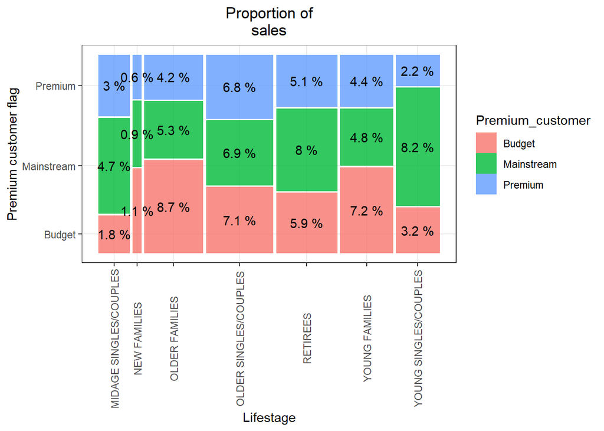

```r
#### Total sales by LIFESTAGE and PREMIUM_CUSTOMER
sales <‐transactionData[, .(SALES = sum(TOT_SALES)), .(LIFESTAGE,Premium_customer)]

#### Create plot
p <‐ ggplot(data = sales) +
geom_mosaic(aes(weight = SALES, x = product(Premium_customer, LIFESTAGE),
fill = Premium_customer)) +
labs(x = "Lifestage", y = "Premium customer flag", title = "Proportion of
sales") +
theme(axis.text.x = element_text(angle = 90, vjust = 0.5))

#### Plot and label with proportion of sales
p + geom_text(data = ggplot_build(p)$data[[1]], aes(x = (xmin + xmax)/2 , y =
(ymin + ymax)/2, label = as.character(paste(round(.wt/sum(.wt),3)*100,
'%'))))
```

Sales are mostly coming from Budget-Older Families, Mainstream-young Singles/Couples and Mainstream Retirees. Budget- Older singles/couples category has a consistent behaviour of purchasing as sales ins constant.

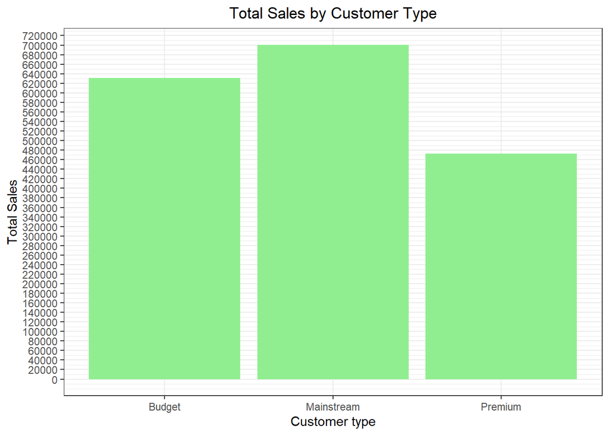

```r
ggplot(transactionData, aes(x = Premium_customer,
                            y = TOT_SALES)) +
  geom_bar(stat = "identity",
           fill = "lightgreen") +
  scale_y_continuous(breaks = seq(0, 800000, 20000)) +
  labs(title = "Total Sales by Customer Type",
       x = "Customer type",
       y = "Total Sales")
```

Mainstream customers are higest followed by Budget Customers so they contribute the most towards the Sales of Chips.

Higher sales may also be driven by more ui=nits of chips being bought per customer. Let us have a look at this:

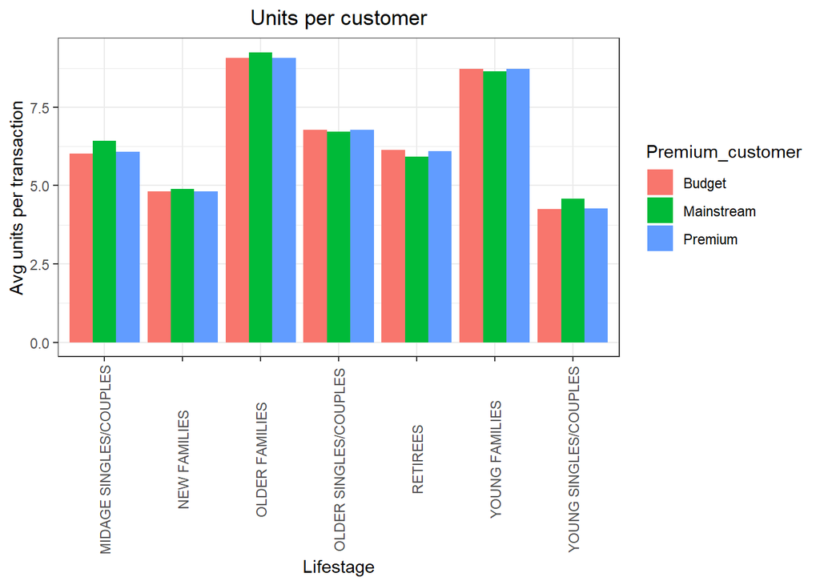

```r
avg_units <‐transactionData[, .(AVG = sum(PROD_QTY)/uniqueN(LYLTY_CARD_NBR)),
.(LIFESTAGE, Premium_customer)][order(‐AVG)]

#Create plot
ggplot(data = avg_units, aes(weight = AVG, x = LIFESTAGE, fill = Premium_customer)) +
geom_bar(position = position_dodge()) +
labs(x = "Lifestage", y = "Avg units per transaction", title = "Units per customer") +
theme(axis.text.x = element_text(angle = 90, vjust = 0.5))
```

Older families and young families in general buy more chips per customer.

Let’s also investigate the average price per unit chips bought for each customer segment as this is also a driver of total sales.

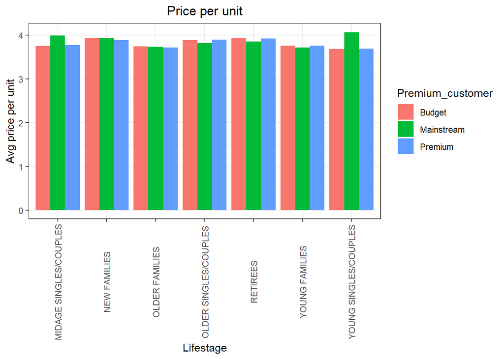

```r
# Average price per unit by LIFESTAGE and PREMIUM_CUSTOMER
avg_price <‐ transactionData[, .(AVG = sum(TOT_SALES)/sum(PROD_QTY)), .(LIFESTAGE,
 Premium_customer)][order(‐AVG)]

#Create plot
ggplot(data = avg_price, aes(weight = AVG, x = LIFESTAGE, fill = Premium_customer)) +
geom_bar(position = position_dodge()) +
labs(x = "Lifestage", y = "Avg price per unit", title = "Price per unit") +
theme(axis.text.x = element_text(angle = 90, vjust = 0.5))
```

Mainstream midage and young singles/couples are willing to pay moreas compared to their budget and premium counterparts. This is because premium coustoemrs might buy chips only for entertainment purposes and would otherwise prefer to buy healty snacks.

As the difference in average price per unit isn’t large, we can check if this difference is statistically different.

```r
# Perform an independent t‐test between mainstream vs premium and budget midage and
# young singles and couples
pricePerUnit <‐transactionData[, price := TOT_SALES/PROD_QTY]
t.test(transactionData[LIFESTAGE %in% c("YOUNG SINGLES/COUPLES", "MIDAGE SINGLES/COUPLES")
 & Premium_customer == "Mainstream", price]
, transactionData[LIFESTAGE %in% c("YOUNG SINGLES/COUPLES", "MIDAGE SINGLES/COUPLES")
 & Premium_customer != "Mainstream", price]
, alternative = "greater")
```

```
##
##  Welch Two Sample t-test
##
## data:  transactionData[LIFESTAGE %in% c("YOUNG SINGLES/COUPLES", "MIDAGE SINGLES/COUPLES") &  and transactionData[LIFESTAGE %in% c("YOUNG SINGLES/COUPLES", "MIDAGE SINGLES/COUPLES") &     Premium_customer == "Mainstream", price] and     Premium_customer != "Mainstream", price]
## t = 37.624, df = 54791, p-value < 2.2e-16
## alternative hypothesis: true difference in means is greater than 0
## 95 percent confidence interval:
##  0.3187234       Inf
## sample estimates:
## mean of x mean of y
##  4.039786  3.706491
```

The t-test results in a p-value < 2.2e-16, i.e. the unit price for mainstream, young and mid-age singles and couples are significantly higher than that of budget or premium, young and midage singles and couples.

###Brand Affinity and Preferred Pack Size of target segment

Now let’s look at the brand affinity to traget and retain customers that contribut the most to the sales of the chips units.

```r
#Deep dive into Mainstream, young singles/couples

segment1 <‐transactionData[LIFESTAGE == "YOUNG SINGLES/COUPLES" & Premium_customer ==
"Mainstream",]


other <- transactionData[!(LIFESTAGE == "YOUNG COUPLES/SINGLES" & Premium_customer == "Mainstream"), ]
```

```r
# Brand affinity compared to the rest of the population
quantity_segment1 <‐ segment1[, sum(PROD_QTY)]
quantity_other <‐ other[, sum(PROD_QTY)]

quantity_segment1_by_brand <‐ segment1[, .(targetSegment = sum(PROD_QTY)/quantity_segment1), by = BRAND]

quantity_other_by_brand <‐ other[, .(other = sum(PROD_QTY)/quantity_other), by= BRAND]


brand_proportions <‐ merge(quantity_segment1_by_brand,quantity_other_by_brand)[, affinityToBrand := targetSegment/other]
brand_proportions[order(‐affinityToBrand)]
```

```
##          BRAND targetSegment       other affinityToBrand
##  1:   Tyrrells   0.031552795 0.026143763       1.2068957
##  2:   Twisties   0.046183575 0.038516238       1.1990676
##  3:    Doritos   0.122760524 0.102744691       1.1948114
##  4:     Kettle   0.197984817 0.168050952       1.1781237
##  5:   Tostitos   0.045410628 0.038550252       1.1779593
##  6:   Pringles   0.119420290 0.102081424       1.1698533
##  7:      Grain   0.029123533 0.025429476       1.1452668
##  8:       Cobs   0.044637681 0.039479251       1.1306618
##  9:  Infuzions   0.064679089 0.057651058       1.1219064
## 10:      Thins   0.060372671 0.057247146       1.0545971
## 11:   Cheezels   0.017971014 0.018594852       0.9664510
## 12:     Smiths   0.089772257 0.110487055       0.8125138
## 13:     French   0.003947550 0.005618634       0.7025818
## 14:    Cheetos   0.008033126 0.011755977       0.6833227
## 15:        RRD   0.043809524 0.065669782       0.6671185
## 16:    NATURAL   0.019599724 0.029987309       0.6536006
## 17:        CCs   0.011180124 0.018301484       0.6108862
## 18:    GrnWves   0.003588682 0.005875863       0.6107498
## 19:      Smith   0.006597654 0.011923920       0.5533125
## 20:   Sunbites   0.006349206 0.012100366       0.5247119
## 21: WOOLWORTHS   0.024099379 0.047476717       0.5076042
## 22:     Burger   0.002926156 0.006313789       0.4634548
##          BRAND targetSegment       other affinityToBrand
```

Let us look what packet size our target buyers prefers to purchase?

```r
#### Preferred pack size compared to the rest of the population
quantity_segment1_by_pack <‐ segment1[, .(targetSegment = sum(PROD_QTY)/quantity_segment1), by = PACK_SIZE]
quantity_other_by_pack <‐ other[, .(other = sum(PROD_QTY)/quantity_other), by = PACK_SIZE]
pack_proportions <‐ merge(quantity_segment1_by_pack, quantity_other_by_pack)[,
affinityToPack := targetSegment/other]

pack_proportions[order(‐affinityToPack)]
```

```
##     PACK_SIZE targetSegment       other affinityToPack
##  1:       270   0.031828847 0.025614425      1.2426142
##  2:       380   0.032160110 0.026090617      1.2326313
##  3:       330   0.061283644 0.051018391      1.2012069
##  4:       134   0.119420290 0.102081424      1.1698533
##  5:       110   0.106280193 0.091060993      1.1671319
##  6:       210   0.029123533 0.025429476      1.1452668
##  7:       135   0.014768806 0.013205810      1.1183567
##  8:       250   0.014354727 0.012901813      1.1126132
##  9:       170   0.080772947 0.080969560      0.9975718
## 10:       150   0.157598344 0.162972285      0.9670254
## 11:       175   0.254989648 0.268850487      0.9484441
## 12:       165   0.055652174 0.061758210      0.9011300
## 13:       190   0.007481021 0.012059975      0.6203182
## 14:       180   0.003588682 0.005875863      0.6107498
## 15:       160   0.006404417 0.011913291      0.5375859
## 16:        90   0.006349206 0.012100366      0.5247119
## 17:       125   0.003008972 0.005803584      0.5184679
## 18:       200   0.008971705 0.017910327      0.5009235
## 19:        70   0.003036577 0.006069316      0.5003162
## 20:       220   0.002926156 0.006313789      0.4634548
```

##CONCLUSION:

[output not shown]